# MeanReversion backtest with Portfolio Optimization

In the chapter 04, we introduced `zipline` to simulate the computation of alpha factors from trailing cross-sectional market, fundamental, and alternative data.

Now we will exploit the alpha factors to derive and act on buy and sell signals using the custom MeanReversion factor developed in the last chapter.

## Imports

```python
import warnings
warnings.filterwarnings('ignore')
```

```python
import sys
from pytz import UTC
import logbook

import pandas as pd
import numpy as np
import matplotlib.pyplot as plt
import seaborn as sns

from logbook import (NestedSetup, NullHandler, Logger,
                     StreamHandler, StderrHandler,
                     INFO, WARNING, DEBUG, ERROR)

from zipline import run_algorithm
from zipline.api import (attach_pipeline,
                         date_rules,
                         time_rules,
                         get_datetime,
                         order_target_percent,
                         pipeline_output,
                         record, schedule_function,
                         get_open_orders,
                         calendars,
                         set_commission,
                         set_slippage)
from zipline.finance import commission, slippage
from zipline.pipeline import Pipeline, CustomFactor
from zipline.pipeline.factors import Returns, AverageDollarVolume

from pypfopt.efficient_frontier import EfficientFrontier
from pypfopt import risk_models, objective_functions
from pypfopt import expected_returns
from pypfopt.exceptions import OptimizationError

from pyfolio.utils import extract_rets_pos_txn_from_zipline
```

```python
sns.set_style('whitegrid')
```

## Logging Setup

```python
# setup stdout logging
format_string = '[{record.time: %H:%M:%S.%f}]: {record.level_name}: {record.message}'
zipline_logging = NestedSetup([NullHandler(level=DEBUG),
                               StreamHandler(sys.stdout, format_string=format_string, level=INFO),
                               StreamHandler(sys.stdout, format_string=format_string, level=WARNING),
                               StreamHandler(sys.stderr, level=ERROR)])
zipline_logging.push_application()
log = Logger('Algorithm')
```

## Algo Settings

```python
# Settings
MONTH = 21
YEAR = 12 * MONTH
N_LONGS = 50
N_SHORTS = 50
MIN_POS = 5
VOL_SCREEN = 1000
```

```python
start = pd.Timestamp('2013-01-01', tz=UTC)
end = pd.Timestamp('2017-01-01', tz=UTC)
capital_base = 1e7
```

## Mean Reversion Factor

```python
class MeanReversion(CustomFactor):
    """Compute ratio of latest monthly return to 12m average,
       normalized by std dev of monthly returns"""
    inputs = [Returns(window_length=MONTH)]
    window_length = YEAR

    def compute(self, today, assets, out, monthly_returns):
        df = pd.DataFrame(monthly_returns)
        factor = df.iloc[-1].sub(df.mean()).div(df.std())
        out[:] = factor
```

## Create Pipeline

```python
def compute_factors():
    """Create factor pipeline incl. mean reversion,
        filtered by 30d Dollar Volume; capture factor ranks"""
    mean_reversion = MeanReversion()
    dollar_volume = AverageDollarVolume(window_length=30)
    return Pipeline(columns={'longs'  : mean_reversion.bottom(N_LONGS),
                             'shorts' : mean_reversion.top(N_SHORTS),
                             'ranking': mean_reversion.rank(ascending=False)},
                    screen=dollar_volume.top(VOL_SCREEN))
```

`Before_trading_start()` ensures the daily execution of the pipeline and the recording of the results, including the current prices.

```python
def before_trading_start(context, data):
    """Run factor pipeline"""
    context.factor_data = pipeline_output('factor_pipeline')
    record(factor_data=context.factor_data.ranking)
    assets = context.factor_data.index
    record(prices=data.current(assets, 'price'))
```

## Set up Rebalancing

It also divests any current holdings that are no longer included in the factor signals:

```python
def exec_trades(data, positions):
    """Place orders for assets using target portfolio percentage"""
    for asset, target_percent in positions.items():
        if data.can_trade(asset) and not get_open_orders(asset):
            order_target_percent(asset, target_percent)
```

```python
def rebalance(context, data):
    """Compute long, short and obsolete holdings; place orders"""

    factor_data = context.factor_data
    assets = factor_data.index

    longs = assets[factor_data.longs]
    shorts = assets[factor_data.shorts]

    divest = context.portfolio.positions.keys() - longs.union(shorts)
    exec_trades(data, positions={asset: 0 for asset in divest})
    log.info('{} | {:11,.0f}'.format(get_datetime().date(),
                                   context.portfolio.portfolio_value))

    # get price history
    prices = data.history(assets, fields='price',
                          bar_count=252+1, # for 1 year of returns
                          frequency='1d')

    # get optimal weights if sufficient candidates
    if len(longs) > MIN_POS and len(shorts) > MIN_POS:
        try:
            long_weights = optimize_weights(prices.loc[:, longs])
            short_weights = optimize_weights(prices.loc[:, shorts], short=True)

            exec_trades(data, positions=long_weights)
            exec_trades(data, positions=short_weights)
        except Exception as e:
            log.warn('{} {}'.format(get_datetime().date(), e))
    # exit remaining positions
    divest_pf = {asset: 0 for asset in context.portfolio.positions.keys()}
    exec_trades(data, positions=divest_pf)
```

## Optimize Portfolio Weights

```python
def optimize_weights(prices, short=False):

    returns = expected_returns.mean_historical_return(
        prices=prices, frequency=252)
    cov = risk_models.sample_cov(prices=prices, frequency=252)

    # get weights that maximize the Sharpe ratio
    ef = EfficientFrontier(expected_returns=returns,
                           cov_matrix=cov,
                           weight_bounds=(0, 1),
                           solver='SCS')
    ef.max_sharpe()
    if short:
        return {asset: -weight for asset, weight in ef.clean_weights().items()}
    else:
        return ef.clean_weights()
```

## Initialize Backtest

The `rebalance()` method runs according to `date_rules` and `time_rules` set by the `schedule_function()` utility at the beginning of the week, right after `market_open` as stipulated by the built-in `US_EQUITIES` calendar (see docs for details on rules).

You can also specify a trade commission both in relative terms and as a minimum amount. There is also an option to define slippage, which is the cost of an adverse change in price between trade decision and execution

```python
def initialize(context):
    """Setup: register pipeline, schedule rebalancing,
        and set trading params"""
    attach_pipeline(compute_factors(), 'factor_pipeline')
    schedule_function(rebalance,
                      date_rules.week_start(),
                      time_rules.market_open(),
                      calendar=calendars.US_EQUITIES)

    set_commission(us_equities=commission.PerShare(cost=0.00075, min_trade_cost=.01))
    set_slippage(us_equities=slippage.VolumeShareSlippage(volume_limit=0.0025, price_impact=0.01))
```

## Run Algorithm

The algorithm executes upon calling the `run_algorithm()` function and returns the backtest performance `DataFrame`.

```python
backtest = run_algorithm(start=start,
                         end=end,
                         initialize=initialize,
                         before_trading_start=before_trading_start,
                         bundle='quandl',
                         capital_base=capital_base)
```

```
[ 19:49:55.661120]: INFO: 2013-01-07 |  10,000,000
[ 19:50:02.961404]: INFO: 2013-01-14 |   9,922,439
[ 19:50:06.101723]: INFO: 2013-01-22 |   9,913,612
[ 19:50:09.110052]: INFO: 2013-01-28 |   9,968,656
[ 19:50:12.293743]: INFO: 2013-02-04 |  10,079,391
[ 19:50:15.636407]: INFO: 2013-02-11 |  10,103,535
[ 19:50:19.025936]: INFO: 2013-02-19 |   9,771,077
[ 19:50:22.454159]: INFO: 2013-02-25 |  10,061,824
[ 19:50:26.025560]: INFO: 2013-03-04 |  10,162,312
[ 19:50:29.300896]: INFO: 2013-03-11 |   9,563,302
[ 19:50:33.294339]: INFO: 2013-03-18 |   9,311,865
[ 19:50:36.611748]: INFO: 2013-03-25 |   9,064,119
[ 19:50:39.810862]: INFO: 2013-04-01 |   8,643,936
[ 19:50:43.357770]: INFO: 2013-04-08 |   8,721,979
[ 19:50:47.126182]: INFO: 2013-04-15 |   8,552,107
[ 19:50:51.070580]: INFO: 2013-04-22 |   8,186,845
[ 19:50:55.027566]: INFO: 2013-04-29 |   9,080,169
[ 19:50:58.655614]: INFO: 2013-05-06 |   8,277,424
[ 19:51:02.617136]: INFO: 2013-05-13 |   8,018,122
[ 19:51:06.524561]: INFO: after split: asset: Equity(189 [AOS]), amount: 62678, cost_basis: 36.54, last_sale_price: 79.9
[ 19:51:06.524914]: INFO: returning cash: 0.0
[ 19:51:07.067627]: INFO: 2013-05-20 |   7,805,480
[ 19:51:11.239217]: INFO: 2013-05-28 |   6,806,488
[ 19:51:15.113238]: INFO: 2013-06-03 |   7,034,540
[ 19:51:19.219741]: INFO: 2013-06-10 |   7,315,434
[ 19:51:23.416837]: INFO: 2013-06-17 |   7,620,513
[ 19:51:27.623110]: INFO: 2013-06-24 |   6,403,342
[ 19:51:31.930314]: INFO: 2013-07-01 |   5,958,489
[ 19:51:36.417751]: INFO: 2013-07-08 |   5,427,714
[ 19:51:42.579167]: INFO: 2013-07-15 |   5,956,660
[ 19:51:47.402413]: INFO: 2013-07-22 |   6,237,875
[ 19:51:51.883184]: INFO: 2013-07-29 |   6,059,791
[ 19:51:55.834086]: INFO: 2013-08-05 |   6,454,247
[ 19:52:00.032541]: INFO: 2013-08-12 |   6,968,293
[ 19:52:04.023979]: INFO: 2013-08-19 |   5,543,339
[ 19:52:07.863710]: INFO: 2013-08-26 |   6,377,059
[ 19:52:12.136057]: INFO: 2013-09-03 |   6,426,491
[ 19:52:15.910429]: INFO: 2013-09-09 |   7,392,591
[ 19:52:20.035565]: INFO: 2013-09-16 |   7,315,055
[ 19:52:25.921373]: INFO: 2013-09-23 |   7,812,821
```

[output cut: 164 more lines]

```
[ 19:59:21.863634]: INFO: 2016-10-10 |   9,007,649
[ 19:59:24.064888]: INFO: 2016-10-17 |   8,642,711
[ 19:59:26.447127]: INFO: 2016-10-24 |   8,723,289
[ 19:59:29.274611]: INFO: 2016-10-31 |   9,861,873
[ 19:59:31.524188]: INFO: 2016-11-07 |  10,512,150
[ 19:59:33.752999]: INFO: 2016-11-14 |   9,782,800
[ 19:59:36.172179]: INFO: 2016-11-21 |   7,302,885
[ 19:59:38.165779]: INFO: 2016-11-28 |   8,179,329
[ 19:59:40.247054]: INFO: 2016-12-05 |   6,719,502
[ 19:59:42.224743]: INFO: 2016-12-12 |   6,428,943
[ 19:59:43.996133]: INFO: 2016-12-19 |   4,324,427
[ 19:59:45.862659]: INFO: 2016-12-27 |   3,500,602
[ 19:59:47.796972]: INFO: Simulated 1008 trading days
first open: 2013-01-02 14:31:00+00:00
last close: 2016-12-30 21:00:00+00:00
```

## Extract pyfolio Inputs

The `extract_rets_pos_txn_from_zipline` utility provided by `pyfolio` extracts the data used to compute performance metrics.

```python
returns, positions, transactions = extract_rets_pos_txn_from_zipline(backtest)
```

## Persist Results for use with `pyfolio`

```python
with pd.HDFStore('backtests.h5') as store:
    store.put('returns/pf_opt', returns)
    store.put('transactions/pf_opt', transactions)
```

```python
with pd.HDFStore('backtests.h5') as store:
    returns_pf = store['returns/pf_opt']
    tx_pf = store['transactions/pf_opt']
    returns_ew = store['returns/equal_weight']
    tx_ew = store['transactions/equal_weight']
```

## Plot Results

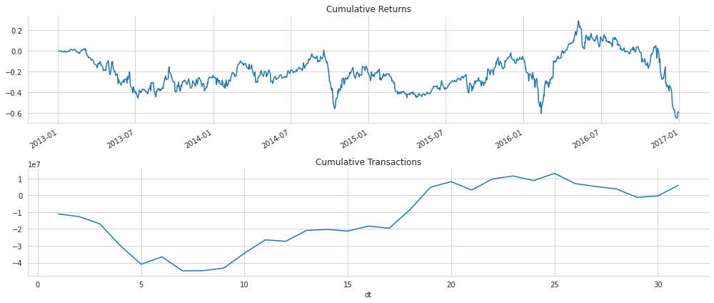

```python
fig, axes= plt.subplots(nrows=2, figsize=(14,6))
returns.add(1).cumprod().sub(1).plot(ax=axes[0], title='Cumulative Returns')
transactions.groupby(transactions.dt.dt.day).txn_dollars.sum().cumsum().plot(ax=axes[1], title='Cumulative Transactions')
sns.despine()
fig.tight_layout();
```

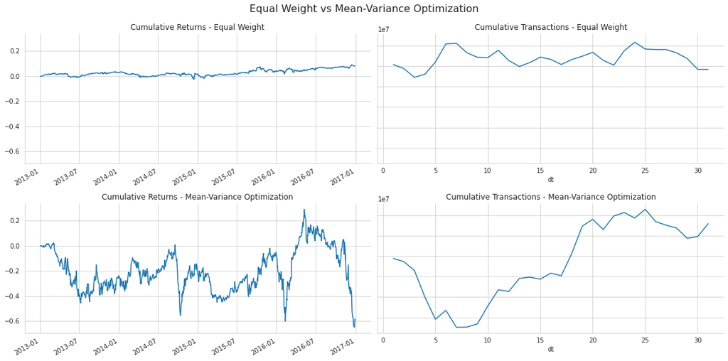

```python
fig, axes = plt.subplots(nrows=2, ncols=2, figsize=(16, 8), sharey='col')
returns_ew.add(1).cumprod().sub(1).plot(ax=axes[0][0],
                                        title='Cumulative Returns - Equal Weight')
returns_pf.add(1).cumprod().sub(1).plot(ax=axes[1][0],
                                        title='Cumulative Returns - Mean-Variance Optimization')
tx_ew.groupby(tx_ew.dt.dt.day).txn_dollars.sum().cumsum().plot(ax=axes[0][1],
                                                               title='Cumulative Transactions - Equal Weight')
tx_pf.groupby(tx_pf.dt.dt.day).txn_dollars.sum().cumsum().plot(ax=axes[1][1],
                                                               title='Cumulative Transactions - Mean-Variance Optimization')
fig.suptitle('Equal Weight vs Mean-Variance Optimization', fontsize=16)
sns.despine()
fig.tight_layout()
fig.subplots_adjust(top=.9)
```